# 2026年04月30日 研究日志

今日主题：汇总数据集GSE135133的样本类别并绘制统计图表。数据集中所有样本均来自美国佛罗里达州 Tampa 的 Florida Lions Eye Bank，包含**5**位没有视网膜疾病的捐献者的视网膜单核RNA测序数据。

[output not shown]

* 区域 1（第 1-8 节）取自后部视网膜，位于视神经出口附近，是视神经基底部之后的冷冻切片后部。区域 2（第 9-18 节）取自稍靠前的后部视网膜，仍包含视网膜色素上皮（RPE），可视为区域 1 的前部延伸。

```r
suppressPackageStartupMessages({
    library(here)
    library(tidyverse)
    library(ggrepel)
    library(Seurat)
    library(SeuratObject)
})
```

↓ 原始数据需要经过大量处理，这里为了演示样本情况直接读取我已经处理好的数据。如果看到这里的您需要数据处理的相关帮助，您可以发邮件联系我，我会在力所能及的范围内尽力协助您。

```r
load("./data/GSE135133.Rdata")
```

```r
# The result which clustered by authors
head(clusters)
```

A data.frame: 6 × 24

|  | cellID <chr> | sampleID <chr> | Tissue <chr> | Sex <chr> | Cell_type_full <chr> | Cell_type_no_rods <chr> | Cell_type_bipolar <chr> | Cell_type_amacrine <chr> | Cell_type_cones <chr> | Cell_type_horizontal <chr> | ⋯ | Clusters_bipolar <int> | Clusters_horizontal <int> | Clusters_cones <int> | Clusters_non_neuronal <int> | Clusters_RPE <int> | Clusters_rods <int> | Clusters_full <int> | Clusters_amacrine <int> | Clusters_myeloid <int> | Clusters_rgc <int> |
| --- | --- | --- | --- | --- | --- | --- | --- | --- | --- | --- | --- | --- | --- | --- | --- | --- | --- | --- | --- | --- | --- |
| 1 | CELL3896072 | SAM24362284 | Left eye | Female | Cones | NA | NA | NA | NA | NA | ⋯ | NA | NA | NA | NA | NA | NA | 26 | NA | NA | NA |
| 2 | CELL3896073 | SAM24362284 | Left eye | Female | Cones | NA | NA | NA | NA | NA | ⋯ | NA | NA | NA | NA | NA | NA | 26 | NA | NA | NA |
| 3 | CELL3896074 | SAM24362284 | Left eye | Female | Cones | NA | NA | NA | NA | NA | ⋯ | NA | NA | NA | NA | NA | NA | 26 | NA | NA | NA |
| 4 | CELL3896075 | SAM24362284 | Left eye | Female | Cones | NA | NA | NA | NA | NA | ⋯ | NA | NA | NA | NA | NA | NA | 26 | NA | NA | NA |
| 5 | CELL3896076 | SAM24362284 | Left eye | Female | Cones | NA | NA | NA | NA | NA | ⋯ | NA | NA | NA | NA | NA | NA | 26 | NA | NA | NA |
| 6 | CELL3896077 | SAM24362284 | Left eye | Female | Cones | NA | NA | NA | NA | NA | ⋯ | NA | NA | NA | NA | NA | NA | 26 | NA | NA | NA |

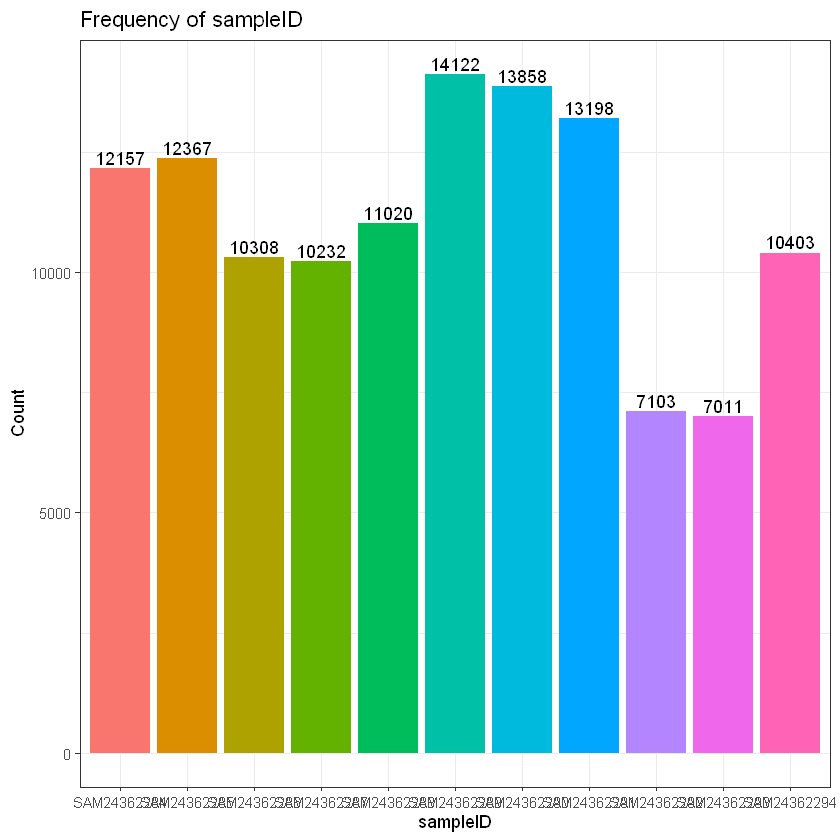

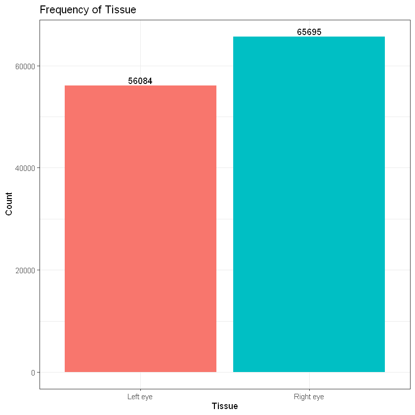

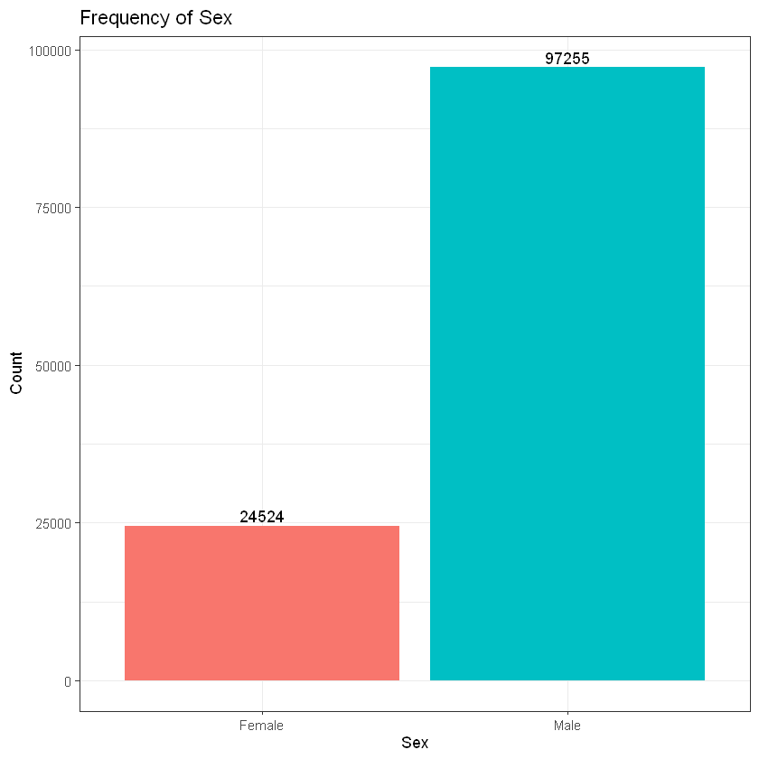

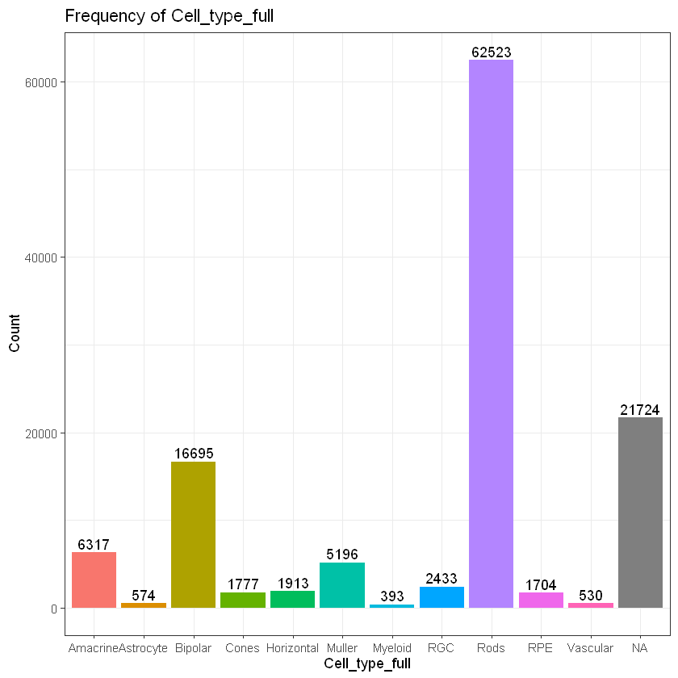

```r
cols_to_plot <- c("sampleID", "Tissue", "Sex", "Cell_type_full")

# 循环绘图
for (col in cols_to_plot) {
  p <- clusters %>%
    count(.data[[col]]) %>%
    ggplot(aes(x = .data[[col]], y = n, fill = .data[[col]])) +
    geom_col() +
    geom_text(aes(label = n), vjust = -0.3) +
    theme_bw() +
    labs(
      title = paste("Frequency of", col),
      x = col,
      y = "Count"
    ) +
    theme(legend.position = "none")

  print(p)
}
```

随便看了一下作者的统计结果。确实视杆细胞压倒性的多呢……从左右眼，还有每个样本的数量看都没有什么问题。虽然从男性捐献者那里明显得到了更多可用的细胞，但都是来自无视网膜疾病的捐献者的视网膜细胞，研究偏倚的风险应该是可控的。接下来稍微看一眼这个单细胞测序数据集的UMAP图吧。

```r
# The Seurat object which clean by myself
class(obj)
```

'Seurat'

```
Rasterizing points since number of points exceeds 100,000.
To disable this behavior set `raster=FALSE`
```

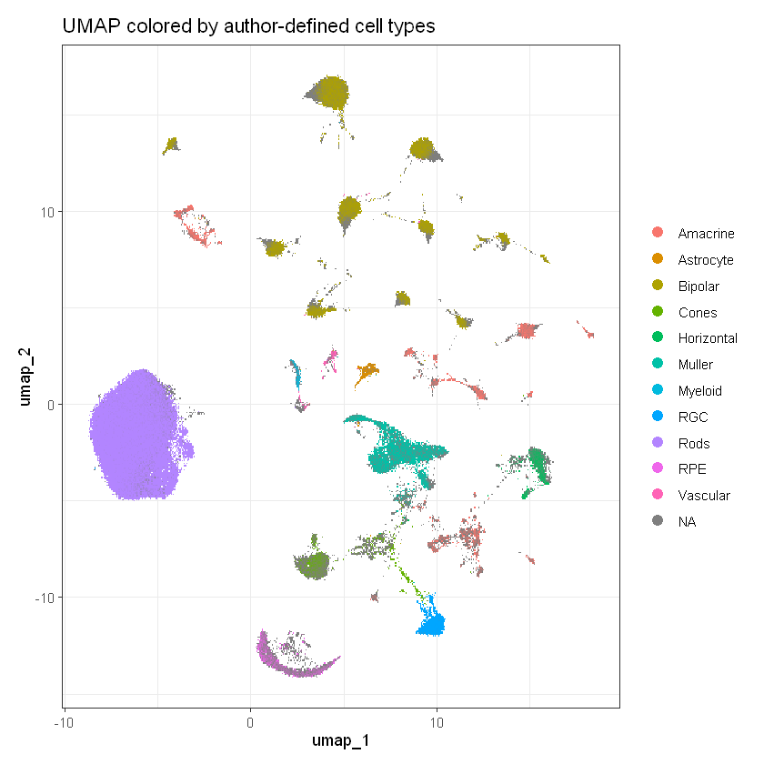

```r
rownames(clusters) <- clusters$cellID
obj$Cell_type_full <- clusters[colnames(obj), "Cell_type_full"]
DimPlot(obj, reduction = "umap", group.by = "Cell_type_full") +
  ggtitle("UMAP colored by author-defined cell types") +
  theme_bw()
```

嗯，这样的全部细胞的俯瞰图也就能看出来视杆细胞的压倒性数量优势了。今天只是做一个大致的浏览和总结，所以今天就到这里了，大家明天再见咯！